# Chapter C11 斜めセミテンションフィールド設計

## パート1. 平らなウェブを持つ梁 / パート2. 曲面ウェブシステム

### パート1

## C11.1 はじめに

航空宇宙構造のエンジニアは、構造重量を節約し、かつ製造および経済的な観点から満足のいく構造を提供するような構造形式や構造解析・設計手法を常に模索している。ウェブの座屈を許容し、せん断荷重をウェブの斜め引張応力によって伝達する構造の開発は、橋梁やビルの梁設計といった他の構造分野における標準的な構造設計手法からの、航空宇宙構造設計における顕著な逸脱の例である。梁ウェブにおける斜めセミテンションフィールド作用を伴うこの新しいタイプの構造設計に関する最初の研究と調査は、Wagner（文献1）によって行われ、この事実から、このタイプの梁設計はしばしばワグナー梁と呼ばれる。

第C10章パート1では、耐せん断性（非座屈）の平らなウェブを持つ梁の設計について扱った。このタイプのウェブ設計は、重量が比較的重くなり、その結果、航空宇宙構造での幅広い使用が制限される。第C10章パート2では、密に配置されたビードやフランジ付き軽量化穴などによって補強されたウェブを扱った。この設計は、垂直補強材を持つ平らなシートウェブに比べてウェブ重量の改善を示している。しかし、航空宇宙構造で使用されるシートパネルの大部分は外面の一部であり、外板に穴や深いビードを設けることは許可されないため、連続したシートが必要となる。構造重量を節約するためには、ウェブおよび外板パネルにおけるセミテンションフィールド作用を許容しなければならず、これはしわを許容するタイプの構造を意味する。

ワグナーによる最初の研究以来、セミテンションフィールド設計を伴う構造に関するさらなる研究と試験が、産業界と政府機関の両方によって数多く実施されてきた。そのため、このような構造の設計のためのかなり正確な手順が開発されており、本章では、関連する原理と開発された設計手順の限定的な紹介について扱う。

## C11.2 テンションフィールド梁の作用に関する初等近似説明

図C11.1は、二重の斜材（A）および（B）を持ち、外力 $P$ を受ける1ベイトラスを示している。荷重 $P$ は、部材（A）に圧縮荷重を、部材（B）に引張荷重を生じさせる。部材（A）が非常に柔軟である場合、荷重 $P$ が比較的小さいとき、図C11.1bに示すように長柱として座屈する。しかし、パネルは崩壊しない。荷重 $P$ が増加するにつれて、部材（A）はそれ以上の荷重を負担できなくなるが、曲げたわみやたわみ量が大きくなっても、実質的にその柱座屈荷重を維持する。しかし、引張状態にある部材（B）は、その極限引張強度に達するまでさらに荷重を負担することができる。したがって、斜材（A）が座屈した後に荷重 $P$ の増加によって生じるパネル内のせん断力の増加は、部材（B）の引張荷重のさらなる増加によって負担される。

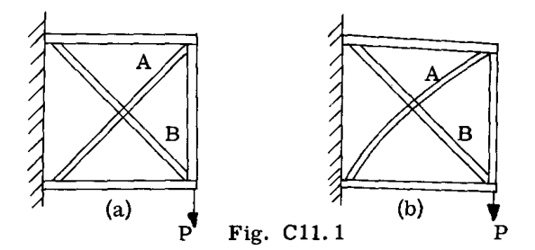

Fig. C11.1

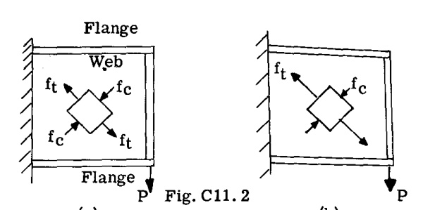

Fig. C11.2

図C11.2は、同じパネルであるが、2本の斜材を平らなシートウェブに置き換えたものである。小さな荷重（ $P$ ）の下では、ウェブは座屈せず、小さなウェブ要素における応力の状態は図C11.2aのようになり、 $f_c = f_t = f_s$ となる。ここで、 $f_s$ はウェブのこの特定の点におけるせん断応力である。薄い平らなシートは圧縮に対して比較的弱いため、パネル荷重 $P$ が増加すると、圧縮応力 $f_c$ は斜め方向のパネルの座屈応力に達し、ウェブは座屈する。しかし、荷重 $P$ のさらなる増加は、ウェブシートにおける $f_t$ または斜め引張のさらなる増加によって対処できるため、パネルは崩壊しない。ウェブは座屈を引き起こした $f_c$ 応力を維持する能力はあるが、それを増加させることはできない。図C11.2bは、荷重 $P$ が大幅に増加した後のウェブ応力状態を示しており、したがって、 $f_t$ のベクトルの長さで示されるように、斜めウェブ引張応力が増加している。パネルのせん断荷重はウェブの斜め引張によって伝達され、平らなシートは引張に対して効率的であるため、このせん断荷重の伝達方法は、引張における許容設計応力が高いため、比較的薄いウェブの使用を可能にする。図C11.3は、荷重下にある薄いウェブ梁の写真を示している。斜めのしわが激しく現れているため、伝達されている外力はウェブの破壊点に近づいていることは疑いない。学生は、通常の飛行加速度の下では、これほどのウェブのしわは発生しないことを理解すべきである。通常の飛行状態で伝達される荷重は設計荷重のわずかな割合にすぎないため、ガスティな気象条件での飛行でよく遭遇する $1/2$ 重力の加速度の下では、座屈やしわはかろうじて気づく程度である。

[figure not shown]

Fig. C11.3

## C11.3 近似テンションフィールド梁公式の初等導出

ウェブのテンションフィールド作用が梁の構成部品に与える影響の全体像を学生に提供するために、梁の方程式の初等近似を示す。

図C11.4は、平行な弦材と垂直な補強材を持ち、自由端で単一のせん断荷重 $V$ を受ける片持ち梁を示している。破線の斜線は、荷重 $V$ の下で薄いシートが座屈するときのしわの方向を示している。

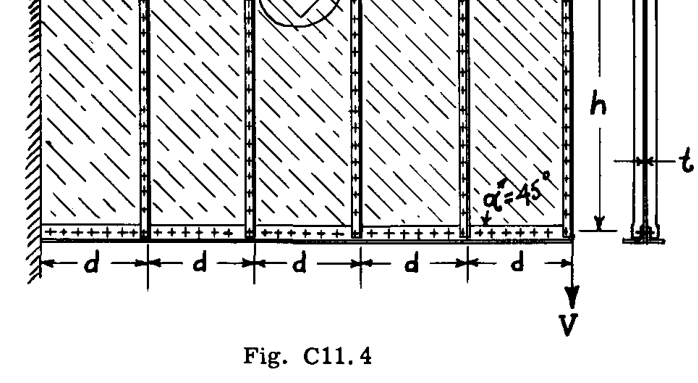

Fig. C11.4

フランジアングルがすべての曲げ抵抗を発達させると仮定すると、垂直および水平のせん断応力はウェブ全体で一定であり、次のように等しくなる。

$$_{fs} = \frac{V}{ht}$$
(1)

ここで、 * $t$ はウェブの厚さ * $h$ はフランジリベットの図心間の距離 * $V$ は垂直せん断荷重

図C11.5は、梁の上部から切り取られたウェブの小さな三角形セグメントのフリーボディ図を示している。

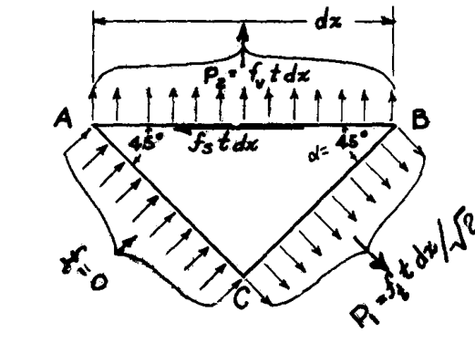

Fig. C11.5

初等力学から、水平および垂直のせん断応力は、せん断平面に対して $45^\circ$ の平面上に圧縮応力と引張応力を生じさせる。

ウェブは非常に薄いため、座屈する前に図C11.5の面（AC）に非常に小さな圧縮応力しか負担できない。したがって、ACに座屈を生じさせるこの小さな応力は無視されるか、または $f_c = 0$ とされる。エッジBCは、シートが効果的に負担できる引張応力を受ける。シート要素に作用する力は図C11.5に示されている。

要素の平衡条件：

$$\Sigma F_x = 0 \quad \text{または} \quad -f_s tdx + f_t
\frac{tdx}{\sqrt{2}} \cdot \frac{1}{\sqrt{2}} = 0$$

これより、

$$_f t = 2 f_s$$
(2)

すなわち、ウェブ引張応力はウェブせん断応力の2倍に等しくなる。

(1)より $f_s = \frac{V}{ht}$

これより、

$$_f t = \frac{2V}{ht}$$
(3)

同様に平衡条件より：

$$\Sigma F_y = 0 \quad \text{または} \quad f_v tdx - f_t
\frac{tdx}{\sqrt{2}} \cdot \frac{1}{\sqrt{2}} = 0$$

これより、

$$_f t = 2 f_v$$
(4)

したがって、

$$_f v = f_s$$
(5)

### リベット荷重

シート要素は、線（AB）に沿ったリベットによってフランジアングルに固定されている。リベットは、ABに平行な荷重とABに垂直な荷重の2つの荷重を受け、それぞれの力は $f_s tdx$ に等しい。したがって、合力としてのリベット荷重は $\sqrt{2} f_s tdx$ に等しくなり、 $dx$ を1インチとすると、合力荷重は $\sqrt{2} f_s t$ となる。

しかし、 $f_s = \frac{V}{ht}$ であるため、

$$\text{リベット荷重/インチ} = 1.41 \frac{V}{h}$$
(6)

### ウェブ補強材荷重

図C11.4における、テンションバンドに分解されたウェブがフランジを互いに引き寄せる傾向は、フランジを離しておく垂直補強材によって防止される。したがって、純粋なテンションフィールドを仮定すると、図C11.6からの補強材の軸圧縮荷重 $P_s$ は、補強材の間隔である距離（ $d$ ）にわたるウェブ引張応力の垂直成分に等しくなる。

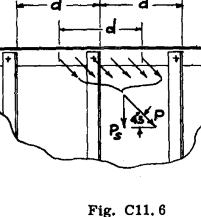

Fig. C11.6

これより、

$$_P s = P \sin \theta$$

しかし、

$$_P = f_t dt \frac{1}{\sqrt{2}}$$

したがって、

$$_P s = \frac{1}{\sqrt{2}} \frac{1}{\sqrt{2}} f_t dt = f_t \frac{dt}{2}$$

しかし、

$f_t = 2 f_s$ および $f_s = \frac{V}{ht}$

これより、

$$\text{補強材荷重 } P_s = \frac{Vd}{h} \text{ (圧縮)}$$
(7)

### フランジ軸荷重

図C11.7は、梁の端部から距離 $x$ の位置にある断面の右側の梁の部分のフリーボディを示している。

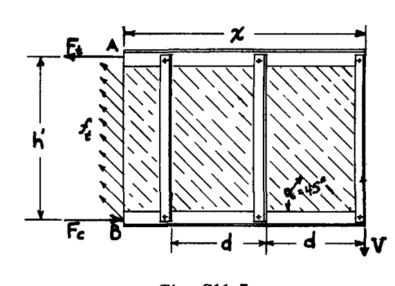

Fig. C11.7

$M_x =$ 断面ABにおける外力曲げモーメントとする。平衡のためには、断面ABにおける内部抵抗モーメントは外力曲げモーメント $M_x$ に等しくなければならない。

点Bの回りのモーメントをとる：

$$\Sigma M_B = M_x - F_t h' - f_t \cos 45^\circ h' t \cdot \cos
45^\circ \frac{h'}{2} = 0$$
(8)

ここで、 * $h' =$ フランジ図心間の距離

しかし、

$f_t = 2 f_s$ および $f_s = \frac{F}{h't}$ 、したがって $f_t = \frac{2V}{h't}$

この $f_t$ の値を式(8)に代入すると、

$$_M x - F_t h' - \frac{Vh'}{2} = 0$$

これより、

$$_F t = \frac{M_x}{h'} - \frac{V}{2}$$
(8a)

したがって、曲げによる圧縮フランジ軸荷重は $\frac{V}{2}$ ポンドに等しい値だけ増加し、曲げによる引張フランジ荷重はウェブテンションフィールドの水平成分のために $\frac{V}{2}$ だけ減少する。

## C11.4 テンションフィールド梁に関する一般的なワグナー方程式

前節で説明した近似的な初等的導出は、完全なテンションフィールド梁が様々な梁応力に与える影響の一般的な概念を学生に提供することを目的としていた。角度 $\alpha$ は一般に $45^\circ$ ではなく、フランジ面積、梁の高さ、補強材の間隔などに依存する。

ワグナー（文献1）によって導出された一般式は以下の通りである。

垂直なウェブ補強材を備えた、無限に剛で平行なフランジを持つ梁の場合：

ウェブにおける斜め引張応力：

$$_f t = \frac{2V}{ht} \cdot \frac{1}{\sin 2 \alpha}$$
(10)

引張フランジにおける軸荷重：

$$_F t = \frac{M}{h'} - \frac{V}{2} \cot \alpha$$
(11)

圧縮フランジにおける軸荷重：

$$_F c = \frac{M}{h'} - \frac{V}{2} \cot \alpha$$
(12)

補強材における軸力：

$$_F \text{Stiff.} = -V \frac{d}{h} \tan \alpha$$
(13)

上記の方程式において： * $V =$ 作用せん断荷重 * $h =$ フランジ・ウェブ・リベットの図心間の距離 * $h' =$ フランジ断面の図心間の距離 * $t =$ ウェブの厚さ * $d =$ 垂直ウェブ補強材の間隔 * $\alpha =$ ウェブ座屈の角度（図C11.7参照）

式(10)から(13)を導出する際、ワグナーは梁のフランジが曲げに対して無限に剛であると仮定した。実際には、ウェブテンションフィールドの横方向の引っ張りにより、フランジは図C11.8aに示すように、ウェブ補強材を支持点とする連続梁のようにある程度作用する。梁フランジのたわみは、パネルの中央部分におけるウェブ応力を緩和し、フランジのたわみが防止されている補強材の近くにウェブ応力を集中させる（図C11.8b参照）。

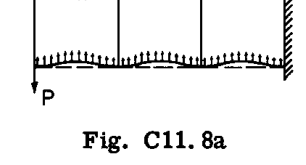

Fig. C11.8a

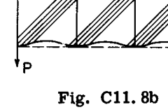

Fig. C11.8b

ワグナー（文献2、パートIII）は、フランジのたわみによるこのウェブ応力集中を考慮するための補正係数 $R$ を開発した。この応力比係数は、図C11.9および以下の方程式から得られる。

$$_{wd} = 1.25 d \sin \alpha \sqrt[4]{\frac{t}{(I_u + I_L)h}}$$
(14)

- $d =$ 補強材の間隔
- $I_u, I_L =$ 上部および下部梁フランジの、それぞれの固有の中立軸に関する慣性モーメント

ワグナーはまた、ウェブの座屈角 $\alpha$ を決定するために以下の方程式を導出した。

$$\sin^2 \alpha = \sqrt{a^2 + a} - a$$
(15)

$$_a = \frac{1 + \frac{ht}{A_u + A_L}}{\frac{dt}{A_s} - \frac{ht}{A_u +
A_L}}$$
(16)

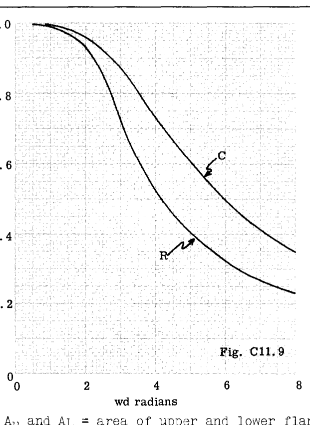

Fig. C11.9

- $A_u, A_L =$ 補強板を含むがウェブ材料は除いた上部および下部フランジの面積
- $A_s =$ 補強材の面積

### 方法1

## C11.5 設計用修正ワグナー方程式

ワグナー方程式は、設計、特にウェブ応力や垂直補強材の荷重に対して保守的すぎる。ウェブが座屈する前に負担するせん断応力は、多くの場合、全抵抗の少なからぬ部分を占める。これは、斜め圧縮応力に垂直な座屈シートが、しわが発生した後もこの座屈せん断荷重を維持する能力を持っているためである。垂直補強材の荷重も保守的すぎる。なぜなら、補強材はウェブにリベットで留められ、ウェブはフランジにリベットで留められているため、ウェブはワグナー方程式で仮定されているピン支持条件ではなく、大きなガセットプレートのように作用するためである。

ワグナー梁の以下の一般的な解析方法は、多くの航空機会社で使用されてきた。梁のせん断力のすべてがウェブの斜め引張によって負担されると仮定する代わりに、梁の垂直せん断力を支持するための抵抗に関して以下の仮定がなされている。

1. 梁フランジのせん断強度は無視しない。
2. ウェブが座屈する前にウェブによって伝達されるせん断、すなわち、耐せん断部材としてのせん断は、有効な抵抗として考慮され、無視しない。
3. (1)および(2)によって伝達される分を差し引いた梁せん断力の残りは、斜めテンションフィールドの形で座屈状態のウェブによって伝達されるとみなされる。

上記の仮定は、平行フランジ部材を持つ梁に適用される。梁に傾斜フランジがある場合、梁せん断力の一部はフランジ軸荷重のせん断成分によって伝達されるため、これらの仮定は正味の梁せん断力に適用されるべきである。

## C11.6 フランジによって伝達されるせん断

一般的な曲げせん断流方程式は以下の通りである。

$$_q = \frac{V \int ydA}{I} = \frac{VQ}{I} \quad (\text{もし } \int ydA
\text{ に記号 } Q \text{ が与えられる場合})$$

航空機構造で一般的に使用される梁フランジおよびウェブの配置では、せん断応力はウェブ全体、すなわちフランジ・ウェブ・リベットの図心間でほぼ一定である。この仮定を使用すると、上記の方程式における $Q$ 値は梁の中立軸に関するフランジ面積の静的モーメントに等しくなり、 $I$ は中立軸に関するフランジ面積の慣性モーメントに等しくなる（ウェブ面積は無視される）。

したがって、ウェブのみによって抵抗されるせん断荷重は次のように等しくなる。

$$_V w = \frac{VQh}{I} = \frac{V}{I / Qh}$$
(17)

ここで、 * $h =$ 有効ウェブ高さ $=$ フランジ・ウェブ接続リベットの図心間の距離

ウェブとフランジの両方の抵抗の合計に等しい全梁せん断力 $V$ は、次のように等しくなる。

$$_V = \frac{V_w I}{Qh}$$
(18)

式(17)と(18)の差がフランジによって伝達されるせん断力を与える。

## C11.7 ウェブによって伝達されるせん断荷重

### ウェブ座屈応力においてウェブにより伝達されるせん断荷重

したがって、ウェブ座屈応力においてウェブによって伝達されるせん断荷重は、以下に等しくなる。

$$_V cr = F_{s_{cr}} h t$$
(19)

限界せん断座屈応力は、第C5章のC5.4から以下の方程式によって与えられる。

$$_F s_{cr} = \frac{\pi^2 k_s E}{12(1 -
u^2)} \left(\frac{t}{b}\right)^2$$
(20)

ここで、 $k_s$ はせん断パネルのアスペクト比 $a/b$ および境界条件の関数である。第C5章の図C5.11は、単純支持されたエッジに対する $k_s$ の値を与えている。この境界条件に対して $k_s$ の値をとることは、間違いなくわずかに保守的である。

### 座屈後にウェブによって伝達されるせん断荷重

したがって、

$$_{f_{t(\text{max.})}} = \left(\frac{f_t}{R} + F_{s_{cr}}\right)$$
(21)

$f_t$ について解くと、

$$_f t = (f_{t(\text{max.})} - F_{s_{cr}}) R$$
(22)

ウェブがフランジおよびウェブ補強材にリベット留めされている場合、リベット穴のためにウェブ材料の一部が削り取られるため、式(21)の引張応力にリベット補正係数 $1/K_r$ を乗じて、真の $f_{t_{\text{max.}}}$ を得る必要がある。

したがって、リベット接続の場合：

$$_{f_{t(\text{max.})}} = \left(\frac{f_t}{R} + F_{s_{cr}}\right)
\frac{1}{K_r}$$
(23)

これより、

$$_f t = \left(f_{t(\text{max.})} - \frac{F_{s_{cr}}}{K_r}\right) K_r R$$
(24)

ここで、

$$_K r = \frac{\text{リベット間隔} -
\text{リベット径}}{\text{リベット間隔}}$$

式(22)は、ウェブがフランジ部材にスポット溶接されている場合に適用される。

合計 $f_t$ 応力の垂直成分は、ウェブの有効高さ（ $h$ ）において、座屈後にウェブによって発達するせん断荷重 $V_t$ に等しくなる。

スポット溶接されたフランジ、ウェブ、および補強材の接続の場合：

$$_V t = (f_{t_{\text{max.}}} - F_{s_{cr}}) R h t \sin \alpha \cos \alpha$$
(25)

リベット接続の場合：

$$_V t = \left(f_{t_{\text{max.}}} - \frac{F_{s_{cr}}}{K_r}\right) K_r R h
t \sin \alpha \cos \alpha$$
(26)

もし $f_{t_{\text{max.}}}$ が引張降伏点応力 $F_{t_y}$ または極限引張応力 $F_{t_u}$ とされる場合、式(25)および(26)は、ウェブがそれぞれ降伏強度および極限引張強度まで応力を受けたときに、座屈荷重を超えてウェブによって伝達されるせん断荷重を与える。

したがって、降伏強度に対して：

$$_V ty = \left(F_{t_y} - \frac{F_{s_{cr}}}{K_r}\right) K_r R h t \sin
\alpha \cos \alpha \quad (\text{リベット接続})$$
(27)

$$_V ty = (F_{t_y} - F_{s_{cr}}) R h t \sin \alpha \cos \alpha \quad
(\text{スポット溶接接続})$$
(28)

極限強度に対して：

$$_V tu = \left(F_{t_u} - \frac{F_{s_{cr}}}{K_r}\right) K_r R h t \sin
\alpha \cos \alpha \quad (\text{リベット接続})$$
(29)

$$_V tu = (F_{t_u} - F_{s_{cr}}) R h t \sin \alpha \cos \alpha \quad
(\text{スポット溶接接続})$$
(30)

ウェブの総降伏せん断抵抗は以下に等しくなる。

$$_V w_{ty} = (V_{cr} + V_{ty})$$
(31)

ウェブの総極限せん断抵抗：

$$_V w_{tu} = (V_{cr} + V_{tu})$$
(32)

したがって、

$$_V \text{yield} = \frac{1}{Qh} (V_{cr} + V_{ty})$$
(33)

$$_V \text{ult.} = \frac{1}{Qh} (V_{cr} + V_{tu})$$
(34)

式(27)から(30)の $V_{ty}$ および $V_{tu}$ の値を代入すると、

スポット溶接接続の場合：

$$_V \text{yield} = \frac{It}{Q} [F_{s_{cr}} + (F_{t_y} - F_{s_{cr}}) R
\sin \alpha \cos \alpha]$$
(35)

$$_V \text{ult.} = \frac{It}{Q} [F_{s_{cr}} + (F_{t_u} - F_{s_{cr}}) R
\sin \alpha \cos \alpha]$$
(36)

リベット接続の場合：

$$_V \text{yield} = \frac{It}{Q} \left[F_{s_{cr}} + \left(F_{t_y} -
\frac{F_{s_{cr}}}{K_r}\right) K_r R \sin \alpha \cos \alpha\right]$$
(37)

$$_V \text{ult.} = \frac{It}{Q} \left[F_{s_{cr}} + \left(F_{t_u} -
\frac{F_{s_{cr}}}{K_r}\right) K_r R \sin \alpha \cos \alpha\right]$$
(38)

## C11.8 平行フランジを持つが斜めウェブ補強材を持つ梁

ワグナーは、補強材が平行なフランジ部材に対してある角度で配置されている場合の式を開発した（図A）。この場合、式(27)から(30)に $(1 - \tan \alpha \cot \beta)$ に等しい補正係数を乗じる必要がある。ここで、 $\beta$ は直立角である。斜め補強材の場合、しわフィールドの角度 $\alpha$ は $\beta/2$ に等しく、集中係数 $R$ は1とみなすことができる。したがって、 $V_{ty}$ および $V_{tu}$ の式は次のようになる。

$$_V ty = \frac{1}{2} \left(F_{t_y} - \frac{F_{s_{cr}}}{K_r}\right) K_r h
t \frac{1 - \cos \beta}{\sin \beta}$$
(38a)

$$_V tu = \frac{1}{2} \left(F_{t_u} - \frac{F_{s_{cr}}}{K_r}\right) K_r h
t \frac{1 - \cos \beta}{\sin \beta}$$
(38b)

（スポット溶接ジョイントの場合は、項 $K_r$ を省略する）

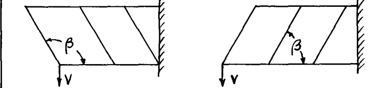

Fig. A

## C11.9 リベット荷重

フランジをウェブに接続するリベットの荷重は、2つの部分から構成される。(1) ウェブが座屈を引き起こす応力を受ける耐せん断部材として作用することによるもの、および (2) ウェブ座屈応力を超えるウェブ応力に対するウェブテンションフィールドによるものである。

### ウェブ座屈応力におけるリベット荷重

$$_P x_{cr} = \frac{V_{cr} I_F}{h I}$$
(39)

ここで、 * $P_{x_{cr}} =$ フランジに平行なリベットへの荷重（lb./in.） * $I_F =$ 梁中立軸に関するフランジの慣性モーメント * $I =$ 全梁断面の慣性モーメント * $h =$ フランジリベット図心間の距離 * $V_{cr} =$ ウェブの座屈せん断強度（lbs.）

### テンションフィールド作用に対するリベット荷重

図C11.11において、ウェブ要素(abc)は線(ab)に沿ってフランジに取り付けられている。1インチの垂直深さ(bc)がとられている。この長さに対する $V_{tu}$ によるせん断応力は $V_{tu}/h$ に等しい。この荷重はテンションフィールドの垂直成分を表すため、

$$_P t = \frac{V_{tu}}{h \sin \alpha}$$
(40)

引張荷重 $P_t$ をリベット線(ab)上の $x$ および $y$ 成分に分解し、長さ $ab$ で除して1インチあたりのリベット荷重を得ると、次式が得られる。

$$_P y = \frac{V_{tu} \sin \alpha \sin \alpha}{h \sin \alpha \cos \alpha}
= \frac{V_{tu}}{h} \tan \alpha$$
(41)

$$_P x = \frac{V_{tu} \cos \alpha \sin \alpha}{h \sin \alpha \cos \alpha}
= \frac{V_{tu}}{h}$$
(42)

式(39)、(42)、および(41)で与えられる3つの成分リベット力を結合して、リベット上の合力荷重 $R$ を得る。

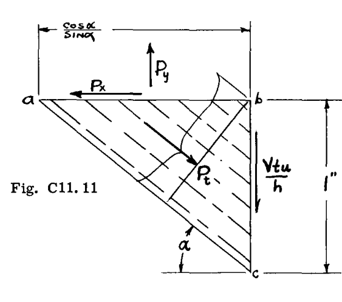

Fig. C11.11

$$_P r = \left[ \left( \frac{V_{cr} I_F}{h I} + \frac{V_{tu}}{h} \right)^2
+ \left( \frac{V_{tu}}{h} \tan \alpha \right)^2 \right]^{1/2}$$
(43)

## C11.10 フランジ荷重

軸方向のフランジ荷重は、主に2つの原因によるものである。すなわち、

1. 通常の曲げ理論による梁の一次曲げによる応力。
2. ウェブテンションフィールドによって生じる追加の応力。

これら2つの主要な影響に加えて、テンションフィールドによるフランジの曲げによる二次曲げ応力が、図C11.8に示すように発生する。

### 一次曲げによる応力：

$$_f b = \pm \frac{M_{cr} y}{I} \pm \frac{(M - M_{cr}) y}{I_F}$$
(44)

ここで、 * $I =$ ウェブを含む全断面の中立軸に関する慣性モーメント * $I_F =$ ウェブを除いた断面の中立軸に関する慣性モーメント * $M_{cr} =$ ウェブの座屈を引き起こす荷重に対する曲げモーメント * $M =$ 断面における全曲げモーメント

上記の方程式の最初の項は、ウェブがテンションフィールドに分解するポイントにおける曲げ応力を与える。したがって、ウェブは慣性モーメント $I$ の計算において有効である。方程式の2番目の項は、梁ウェブがテンションフィールドウェブとして作用するときの曲げ応力を与える。言い換えれば、座屈したウェブは曲げに対して無効であると仮定される。

わずかに保守的であるために、曲げ応力は座屈前の曲げにおけるウェブの抵抗を無視する以下の方程式によって計算できる。

$$_f b = \pm \frac{My}{I_F}$$
(45)

全フランジ荷重は、内部抵抗偶力を外部曲げモーメントに等しくすることによって計算できる。すなわち、

$$_F c = F_t = \pm \frac{M}{h'}$$
(46)

ここで、 * $F_c$ および $F_t =$ それぞれ全圧縮および引張フランジ荷重 * $h' =$ フランジ図心間の距離

式(46)は、曲げにおけるウェブの抵抗を無視している。

### ウェブテンションフィールドによるフランジ軸応力

斜めテンションフィールドの水平成分のため、各フランジは以下に等しい圧縮荷重を受ける。

$$_F c = F_t = -\frac{V_t}{2} \cot \alpha$$
(47)

（参考として、式(12)および $\alpha = 45^\circ$ のときの一般的導出である式(8)および(9)を参照）。

式(47)において、 $V_t =$ テンションフィールド作用によって伝達されるせん断荷重。

### 二次曲げ応力

ウェブテンションフィールドの横方向の引っ張りによるフランジ上の二次曲げモーメントを推定するために、フランジは補強材の間隔に等しいスパンを持つ連続梁として扱うことができる。

フランジに垂直なウェブ斜め引張応力の成分：

$$_w v = \frac{V_t}{h} \tan \alpha \quad (\text{ポンド/インチ})$$
(48)

ここで、 * $V_t =$ 斜め引張においてウェブにより伝達されるせん断力

等スパンの連続梁の場合、支持点上のモーメント $= 1/12 w_v d^2$ である。ここで、 $d$ は補強材の間隔に等しい。フランジのたわみは補強材間の境界部分における引っ張りを緩和する傾向があり、これにより支持点上の連続モーメントが減少する。ワグナー（文献1）は、曲げモーメント式で使用するための緩和係数 $C$ （図C11.9参照）を与えている。

したがって、フランジ上の二次曲げモーメントは以下の通りである。

$$_M \text{sec} = 1/12 C \frac{V_t}{h} d^2 \tan \alpha$$
(49)

## C11.11 ウェブ垂直補強材の荷重

垂直ウェブ補強材の強度をチェックする以下の方法は、もともとワグナー（文献1、2）によって提案されたものであり、保守的であると考えることができる。

ウェブ補強材における軸柱荷重は以下に等しくなる。

$$_F \text{stiff.} = -V_t \frac{d}{h} \tan \alpha$$
(50)

これは、 $V$ が斜めテンションフィールド作用においてウェブによって伝達されるせん断力 $V_t$ に置き換えられている点を除いて、式(13)と同じである。この荷重の下で、ワグナーは、ウェブの引張が支柱のウェブ平面外への座屈を抑制するため、補強材を弾性支持を持つ柱とみなしている。ワグナーの計算は、補強材の実際の長さに乗じて減少した長さ $L'$ を得るための減少係数 $C_2$ を与える。すなわち、

$$_L' = C_2 L$$
(50a)

ワグナーの研究以来、NACAはセミテンションフィールド梁の強度と設計に関する広範な研究プログラムを実施しており、ウェブ補強材の強度設計はより合理的な基準に基づいている。NACAの方法は本章の後半で説明されており、ウェブ補強材の最終チェックには、NACAの方法を使用することが推奨される。もともとワグナーによって提案された上記の方法は、ウェブ補強材の迅速な予備設計に使用することができる。

## C11.12 非平行フランジを持つ梁

多くの航空機用梁において、フランジは平行ではなく、わずかなテーパーを持っている。この場合、式(46)および(47)はフランジ荷重の水平成分のみを与える。総フランジ力とその垂直成分は、水平成分とフランジの傾斜から計算することができる。したがって、図C11.12aから、フランジ力の垂直成分を差し引くことにより、正味のウェブせん断荷重 $V_{w_n}$ を得る。

$$_V w_n = V_w - (F_t \tan \theta_t + F_c \tan \theta_c)$$
(51)

ここで、 * $V_{w_n} =$ 非平行フランジを持つ梁の正味ウェブせん断力 * $V_w =$ 平行フランジを持つ梁のウェブせん断力

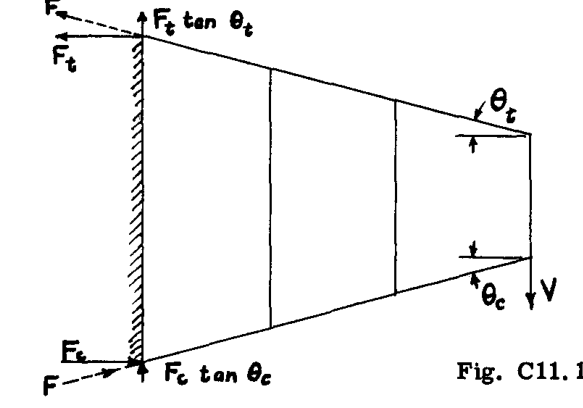

Fig. C11.12a

## C11.13 方法1を使用した例題

- ウェブ：2024-T3 アルミシート。 $F_{t_u} = 64000$ 、 $F_{t_y} = 42000$ 、 $E = 10,500,000$
- フランジ：7075-T6 アルミ合金押出材。 $F_{t_u} = 78000$ 、 $F_{t_y} = 70000$ 、 $E = 10,300,000$

### ウェブ強度の調査

ウェブ補強材とフランジリベットの図心間のウェブパネルサイズ $= 10 \times 28.56$

パネルのアスペクト比 $= a/b = 28.56 / 10 = 2.856$

限界座屈せん断応力は、第C5章の式C5.4によって与えられる。

$$_F s_{cr} = \frac{\pi^2 k_s E}{12(1 -
u^2)} \left(\frac{t}{b}\right)^2$$
(A)

$a/b$ 比が 2.856 で、単純支持されたエッジに対する座屈係数 $k_s$ は、第C5章の図C5.11から得られ、 $k_s = 5.8$ となる。(A)に代入すると、

$$_F s_{cr} = \frac{\pi^2 \times 5.8 \times 10,500,000}{12(1 - 0.3^2)}
\left(\frac{0.025}{10}ight)^2 = 342 \text{ psi}$$

したがって、座屈応力までにウェブによって発達するせん断荷重抵抗は、以下に等しくなる。

$$_V cr = F_{s_{cr}} h t = 342 \times 28.56 \times 0.025 = 244 \text{ lb.}$$

座屈後のテンションフィールドとして作用するウェブのせん断強度は、引張降伏点応力を受けるとき、以下の式によって与えられる。

$$_V ty = \left(F_{t_y} - \frac{F_{s_{cr}}}{K_r}ight) K_r R h t \sin
\alpha \cos \alpha \quad (\text{式27参照})$$

引張極限応力を受けるとき、

$$_V tu = \left(F_{t_u} - \frac{F_{s_{cr}}}{K_r}ight) K_r R h t \sin
\alpha \cos \alpha \quad (\text{式29参照})$$

これらの式を解く前に、項 $\alpha$ 、 $R$ 、および $K_r$ を決定する必要がある。

水平に対する斜めテンションフィールドの角度は次の通りである。

$$\sin^2 \alpha = \sqrt{a^2 + a} - a \quad (\text{式15参照})$$

ここで、

$$_a = \frac{1 + \frac{ht}{A_u + A_L}}{\frac{dt}{A_s} - \frac{ht}{A_u +
A_L}} \quad (\text{式16参照})$$

代入すると、

$$_a = \frac{1 + \frac{28.56 \times 0.025}{0.675 + 0.378}}{\frac{10 \times
0.025}{0.23} - \frac{28.56 \times 0.025}{0.675 + 0.378}} = 4.05$$

したがって、

$$\sin^2 \alpha = \sqrt{4.05^2 + 4.05} - 4.05 = 0.47$$

$\sin \alpha = 0.685$ 、 $\alpha = 43^\circ$ 、 $\cos \alpha = 0.73$

ウェブ応力集中係数 $R$ を決定するために、項 $wd$ について解き、図C11.9の曲線を使用する。

$$_{wd} = 1.25 d \sin \alpha \sqrt[4]{\frac{t}{(I_u + I_L)h}} \quad
(\text{式14参照})$$

$$_{wd} = 1.25 \times 10 \times 0.685 \sqrt[4]{\frac{0.025}{(0.1075 +
0.0291) 28.56}} = 2.43$$

図C11.9の曲線から、 $R = 0.86$

ウェブはフランジにリベット留めされているため、ウェブの正味面積に対しても補正を行う必要がある。

$$_K r = \frac{\text{リベット間隔} -
\text{リベット径}}{\text{リベット間隔}} = \frac{0.75 - 0.156}{0.75} =
0.79$$

2024-T3 材料の場合、 $F_{t_y} = 42000$ および $F_{t_u} = 64000 \text{ psi}$

$$_V ty = \left(42000 - \frac{342}{0.79}ight) \times 0.79 \times 0.86
\times 28.56 \times 0.025 \times 0.685 \times 0.73$$

$$_V ty = (41565) \times 0.242 = 10100 \text{ lb.}$$

$$_V tu = \left(64000 - \frac{342}{0.79}ight) \times 0.242 = 15400 \text{
lb.}$$

フランジの強度を含む全せん断荷重は、式(33)および(34)によって与えられる。すなわち、

$$_V \text{yield} = \frac{1}{Qh} (V_{cr} + V_{ty})$$

$$_V \text{ult.} = \frac{1}{Qh} (V_{cr} + V_{tu})$$

ウェブを除いた断面の $I_{\text{N.A.}} = 210 \text{ in.}^4$

中立軸に関するフランジの $Q = 7.15$

$$_V \text{yield} = \frac{210}{7.15 \times 28.56} (244 + 10,100) = 10,670
\text{ lb.}$$

$$_V \text{ult.} = \frac{210}{7.15 \times 28.56} (244 + 15,400) = 16,070
\text{ lb.}$$

設計極限せん断荷重 $= 13,500 \text{ lb.}$

したがって、

$$\text{M.S.} = (16,070 / 13,500) - 1 = 0.19$$

1.5の安全率を使用した作用せん断荷重は $13,500 / 1.5 = 9000 \text{ lb.}$ である。

降伏強度は $10,670 \text{ lb.}$ である。したがって、作用荷重に対する降伏強度の安全余裕（M.S.）は、 $(10,670 / 9000) - 1 = 0.18$ となる。

この結果は、梁のせん断抵抗が、総極限強度 $16,070 \text{ lb.}$ に対して以下のように配分されていることを示している。 * $(244 / 16,070) \times 100 = 1.5\%$ ：純粋なせん断状態のウェブによって伝達される。 * $(15,400 / 16,070) \times 100 = 96.0\%$ ：斜めテンションフィールドとしてウェブによって伝達される。

残りの $2.5\%$ は、フランジのせん断強度によって伝達される。この値はこの特定の梁に対して比較的低いが、一般にフランジはより多くの抵抗を提供する可能性がある。薄いウェブ厚さと大きなウェブパネルのため、ウェブは比較的低い応力で座屈し、したがって座屈応力においてウェブによって伝達される外力せん断力の割合は非常に小さい。

### リベット接続のチェック - ウェブからフランジ

$0.025$ のウェブは、 $3/4$ インチ間隔の $5/32$ 径 2117-T3 リベットの2列によってフランジ部材に取り付けられている。

フランジの1インチあたりのリベットへの合力荷重は、式(43)すなわち式(B)によって与えられる。

$$_P r = \left[ \left( \frac{V_{cr} I_F}{h I} + \frac{V_{tu}}{h} \right)^2
+ \left( \frac{V_{tu}}{h} \tan \alpha \right)^2 \right]^{1/2} \quad
--(B)$$

与えられたせん断荷重 $13,500 \text{ lb.}$ の下でテンションフィールドによって伝達されるせん断荷重：

$$13500 = \frac{210}{7.15 \times 28.56} (244 + V_t)$$

$$13500 = 1.03 (244 + V_t)$$

これより、

$V_t = 12,850 \text{ lb.}$ 。これは、 $P_r$ の式(B)における $V_{tu}$ を表す。

式(B)に代入する：

$$_P r = \left[ \left( \frac{244}{28.56} \frac{210}{270.5} +
\frac{12850}{28.56} \right)^2 + \left( \frac{12850}{28.56} \times 0.933
\right)^2 \right]^{1/2}$$

$$_P r = [(6 + 450)^2 + 420^2]^{1/2} = 624 \text{ lb./インチ}$$

$0.75$ インチのリベットピッチあたりの荷重 $= 0.75 \times 624 = 468 \text{ lb.}$

$5/32$ - 2117-T3 リベットの単一せん断強度 $= 596 \times 0.86 = 512 \text{ lb.}$ （第D1章参照）。

2024-T3 シートの支圧強度 $= 1.24 \times 392 = 486 \text{ lb.}$ （第D1章参照）。

支圧が臨界であり、リベットピッチあたりのリベット強度は $2 \times 486 = 972 \text{ lb.}$ （リベット2列）である。

$$\text{安全余裕 (Margin of Safety)} = (972 / 468) - 1 = 1.08$$

M.S.が大きいため、リベット径を $1/8$ インチにするか、または $5/32$ リベットの間隔をさらに広げることができる。

### フランジ強度のチェック

片持ち梁の端部ベイは、2つの梁フィッティングや特別な端部補強材など、特別な設計上の考慮事項を伴う。したがって、基本的なフランジ面積は、端部フィッティングがフランジ部材から荷重を取り出し始める可能性のある、載荷点から50インチの位置にある断面A-Aでチェックされる。

梁断面A-Aにおける設計曲げモーメントは、

$$50 \times 13,500 = 675,000 \text{ in.
lb.}$$
である。

$V_{cr} = 244 \text{ lb.}$ （ウェブが座屈せずに伝達するせん断荷重）であるため、 $244 \text{ lb.}$ のせん断力による曲げモーメントは、ウェブを含む全断面によって抵抗される。この値を超えると、残りのモーメントは、慣性モーメントの計算においてウェブを無視した断面によって抵抗される。

したがって、ウェブ座屈荷重における曲げモーメント $= 244 \times 50 = 12,200 \text{ in. lb.}$

テンションフィールド梁の曲げモーメント $= 675,000 - 12,200 = 662,800 \text{ in. lb.}$

### 曲げ応力

#### 上部フランジ曲げ応力：

$$_f b = - \frac{12200 \times 12.58}{270.5} - \frac{662,800 \times
10.94}{210}$$

（式44参照）

$$= -567 - 34600 = -35,167 \text{
psi}$$

仮に全曲げモーメントがフランジのみによって抵抗されると仮定した場合、

$$_f b = - \frac{675000 \times 10.94}{210} = -35,200 \text{ psi}$$

#### 下部フランジ曲げ応力

$$_f b = - \frac{12200 \times 17.42}{270.5} + \frac{662800 \times
19.06}{210}$$

$$= 783 + 60200 = 60,980 \text{
psi}$$

（注：断面特性は、フランジT字材の垂直脚にある1つの $5/32$ リベット穴を差し引かずに計算されたため、応力はわずかに非保守的である。安全側にするために、応力を計算する際には正味の断面特性を使用する必要がある）。

### 曲げによる平均軸フランジ荷重

$$\text{全フランジ荷重} = \frac{M}{h'} = \frac{675000}{29.45} = 22,900
\text{ lb.}$$

上部フランジ $f_{c_{\text{aver.}}} = -22900 / 0.675 = -33,900 \text{ psi}$

下部フランジ $f_{t_{\text{aver.}}} = 22900 / 0.378 = 60,500 \text{ psi}$

### テンションフィールド作用によるフランジ軸荷重

ウェブの斜め引張による各フランジの軸荷重は、以下に等しくなる。

$$_F t = F_c = -0.5 V_t \cot \alpha \quad (\text{式47参照})$$

$$= -0.5 \times 12850 \times 1.07 =
-6860$$

上部フランジの平均応力

$$f_c = -6860 / 0.675 = -10,170 \text{
psi}$$

下部フランジ $f_t = -6860 / 0.378 = -18,180 \text{ psi}$

### 複合フランジ軸応力

#### 上部フランジ - 最外縁繊維

$$f_c = -35167 - 10770 = -45,337 \text{
psi}$$

平均応力：-

$$f_{c_{\text{av.}}} = -33900 - 10170 =
-44,070 \text{ psi}$$

#### 下部フランジ - 最外縁繊維

$$f_t = 60980 - 18180 = 42,800 \text{
psi}$$

平均 $f_t = 60500 - 18180 = 42,320 \text{ psi}$

テンションフィールド作用は下部フランジの引張荷重を減少させる傾向があるため、テンションフィールド作用は厳密な理論ではないことから、軽減効果の全体を含めないことが推奨される。

### フランジ二次曲げ応力

ウェブは斜め引張状態にあるため、フランジ部材を引っ張る。言い換えれば、各フランジは、ウェブ補強材を支持点とし、フランジ上の横方向荷重がウェブ斜め引張応力の垂直成分に等しい連続梁として作用する。この二次曲げモーメントは、式(49)によって近似される。

$$_M \text{sec.} = 1/12 C \frac{V_t}{h} d^2 \tan \alpha$$

図C11.9から、 $wd = 2.43$ のとき $C = 0.925$

これより、

$$_M \text{sec.} = 1/12 \times 0.925 \times \frac{12850}{28.56} \times
10^2 \times 0.933 = 3230 \text{ in. lb.}$$

#### 上部フランジの二次曲げ応力

下側繊維の $I/y = 0.1075 / 1.16 = 0.0925$

上側繊維の $I/y = 0.1075 / 0.338 = 0.318$

$$_f b_{\text{(下側繊維)}} = 3230 / 0.0925 = 34,900 \text{ psi}$$

フランジが支持点上で曲がるときの圧縮。

$$_f b_{\text{(上側繊維)}} = 3230 / 0.318 = 10,140 \text{ psi (引張)}$$

したがって、下側繊維における複合応力は、

$$-34900 - 44070 = -78,970 \text{
psi}$$
となる。

上側繊維における複合応力は、

$$10140 - 45337 = -35,197 \text{
psi}$$
となる。

#### 下部フランジの二次曲げ応力

上側繊維の $I/y = 0.0291 / 0.939 = 0.031$

$$_f b_{\text{(上側繊維)}} = 3230 / 0.031 = 104,000 \text{ psi (圧縮)}$$

$$_f b_{\text{(下側繊維)}} = 3230 / 0.134 = 24,100 \text{ psi (引張)}$$

下部フランジにおける複合応力は以下の通りである。

$$f_{\text{(上側繊維)}} = 42320 - 104000 =
-61,680 \text{ psi}$$

$$f_{\text{(下側繊維)}} = 42800 + 24100 =
66,900 \text{ psi}$$

### 上部フランジの破壊圧縮応力の計算

隣接する構造からの横方向のブレースによって横方向の柱作用が防止されていると仮定するため、フランジの破壊は局所座屈によるものとなる。

$$\frac{A}{gt^2} \left( \frac{F_{c_y}}{E_c} \right)^{1/2} =
\frac{0.675}{4 \times 0.1562^2} \left( \frac{70,000}{10,300,000}
\right)^{1/2} = 0.572$$

図C7.7から、 $F_{c_s} / F_{c_y} = 0.90$ を読み取る。

したがって、圧縮において $F_{c_s} = 0.9 \times 70,000 = 63,000 \text{ psi}$ となる。

フランジの二次曲げの影響を除くと、上部フランジの平均軸応力は以前に $-44,070 \text{ psi}$ と計算されていた。したがって、安全余裕は以下のようになる。

$$(63,000 / 44,070) - 1 =
0.43$$

しかし、上部フランジは、ウェブ垂直補強材を支持点としてフランジが連続梁として作用することによる応力も負担しなければならない。支持点上におけるこの曲げモーメントは、以前に $3230 \text{ in. lbs.}$ と計算されていた。支持点間の中央における曲げモーメントは、フランジの横方向のたわみが緩和効果を生み出すため、この値の約50パーセントになる。以前の計算では、上部繊維における複合応力は $-35,197 \text{ psi}$ 、下部繊維における複合応力は $-78,970 \text{ psi}$ となった。この圧縮応力は、7075-T6材料の $F_{c_y}$ 値である $70,000$ を超えており、したがってT字材の垂直脚が明らかに弱い。垂直脚の許容平均応力は、それを等辺山形鋼断面の一部とみなし、第C7章のニードハム（Needham）の方法によって座屈応力を計算することで計算できる。結果は $-51,500 \text{ psi}$ となり、したがって $-78,970$ の応力が存在することから、既存の弱さが示され、再設計が必要である。

図Aは、以前と同じ面積を持ち、重量を増加させないフランジ断面の再設計を示している。T字材の高さは $0.5$ インチ高くされ、T字材の底部に $0.5$ インチ幅のリップが追加された。追加された面積を相殺するために、厚さとバルブサイズが縮小されている。新しい断面特性は図Aに示されている。

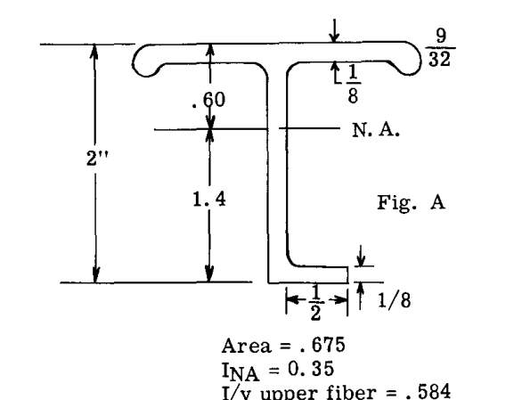

Fig. A

$$\text{面積} = 0.675$$

$$_I_{\text{N.A.}} = 0.35$$

$$I/y \text{ 上側繊維} = 0.584$$

$$I/y \text{ 下側繊維} = 0.25$$

二次曲げ応力は以下のように再計算される。

下側繊維における複合応力は、T字材が修正される前の以前の値 $-78,970$ に対し、 $-44,070 - 12,900 = -56,970 \text{ psi}$ である。T字材の底部にリップを追加すると、許容応力は以前に計算された $-51,500$ を超えて上昇するため、 $-56,970$ の応力を伝達することができる。

この例題は、二次曲げ応力を減少させるためにフランジの設計に適切な注意を払わない限り、二次曲げ応力が主要な応力要因になり得るという事実を明らかにしている。

フランジの強度を計算またはチェックする別の方法は、以下の相互作用公式を使用することである。

$$R_c + R_b = 1$$

ここで、 $R_c$ は梁の曲げおよびウェブの斜め引張効果によるフランジ荷重を、フランジ断面の座屈応力 $F_{c_s}$ で除したものである。

### ウェブ垂直補強材の強度のチェック

ウェブ補強材における柱荷重は、式(50)で与えられる。

$$_F \text{stiff.} = -V_t \frac{d}{h} \tan \alpha$$

$$= -12850 \times \frac{10}{28.56} \times
0.933 = -4200 \text{ lb.}$$

$$\frac{d}{h(\cot \alpha - \cot \beta)} = \frac{10}{28.56(\cot 40^\circ)}
= 0.304$$

これにより $C_2 = 0.38$ となる。

したがって、

$$L' = 0.38 \times 28.56 =
10.8\text{''}$$

補強材として機能するウェブシートの有効幅を $30t$ と仮定すると、 $1 \times 1 \times 1/8$ のアングル補強材の回転半径は $0.267$ 、面積は $0.253$ となる。

したがって、

$$L'/\rho = 10.8 / 0.267 =
40.5$$

座屈応力は、第C7章のニードハムの方法によって計算される。

$$b'/t = 0.9375 / 0.125 =
7.5$$

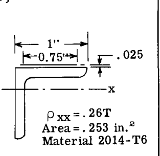

NACA Stiffener

第C7章の図C7.3から、 $F_{c_s} / \sqrt{F_{c_y} E} = 0.07$ 。 $F_{c_s} = 0.07 \sqrt{53000 \times 10,700,000} = 52,500 \text{ psi}$ 。

第C7章のジョンソン・オイラー（Johnson-Euler）の公式を使用すると、

$$_F c = F_{c_s} - \frac{F_{c_s}^2}{4\pi^2 E} (L'/\rho)^2$$

$$_F c = 52500 - \frac{52,500^2}{4\pi^2 \times 10,700,000} (40.5)^2 =
41,800 \text{ psi}$$

補強材強度 $= P = F_c A = 41,800 \times 0.253 = -10,600 \text{ lb.}$

荷重はわずか $4200 \text{ lb.}$ であるため、補強材は大幅に強度過剰であり、構造重量を節約するために再設計されるべきである。

### 方法2

## C11.14 平らなウェブを持つセミテンションフィールド梁のNACA強度解析方法

方法1、すなわち例題で使用された修正ワグナー方程式および手順は、ウェブおよびウェブ補強材の設計に関してやや保守的である。この保守性を排除し、ウェブおよび補強材の設計をより合理的かつ真の基準に置くために、NACAはセミテンションフィールド梁の作用に関するより深い理解を開発し、航空宇宙構造エンジニアが使用するための設計手順を提示するために、包括的な研究および試験プログラムを実施した。このプログラムの結果は（文献3および4）に要約されている。以下の内容は、それらの報告書から引用したものである。

### NACA記号

以下の記号リストは、本章の最初の部分で使用された記号と一致させるために、 $\sigma$ 、 $\tau$ 、 $\sigma_0$ がそれぞれ $f_n$ 、 $f_s$ 、 $F_u$ に置き換えられている点を除き、文献3および4で使用されているものと同じである。

- $A =$ 断面積（平方インチ）
- $E =$ ヤング率（KSI）
- $G =$ せん断弾性係数（KSI）
- $P =$ 力（KIPS）
- $Q =$ サブスクリプトで指定された断面の部分の中立軸に関する静的モーメント（in.）
- $R =$ 端部拘束係数
- $S =$ 横せん断力（kips）
- $d =$ 垂直材の間隔（インチ）
- $e =$ ウェブの中間面から（単一の）垂直材の図心までの距離（インチ）
- $h =$ 梁の高さ（インチ）
- $k =$ 斜め引張係数
- $t =$ 厚さ（インチ、サブスクリプトなしで使用される場合はウェブの厚さを表す）
- $\alpha =$ 梁の中立軸と斜め引張の方向との間の角度（度）
- $\rho =$ ウェブに平行な軸に関する垂直材の断面積の図心回転半径（インチ、シートを含まない）
- $f_n =$ 法線応力（ksi）
- $f_s =$ せん断応力（ksi）

#### サブスクリプト

- $DT =$ 斜め引張
- $F =$ フランジ
- $S =$ せん断
- $u =$ 垂直材
- $W =$ ウェブ
- $cr =$ 限界
- $ult =$ 極限
- $e =$ 有効

## C11.15 不完全斜め引張の工学理論

薄い平らなシートをウェブとして持つ梁において、外力せん断荷重がウェブの座屈荷重未満である場合、ウェブは図C11.14（図a）に示すように、中立軸において純粋なせん断状態にある。ウェブの高さにわたる曲げによる法線応力を無視すると、このせん断応力分布はウェブの全高にわたって一定であると仮定できる。

ウェブが薄い場合、ある限界荷重の下で座屈し、荷重がこの限界座屈値を超えて増加すると、座屈パターンは図C11.14bに示すように純粋なテンションフィールドに近づく。

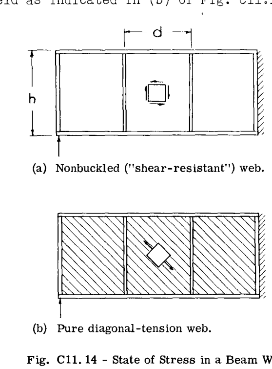

Fig. C11.14

航空機構造における通常の実際の薄いウェブ梁では、ウェブの応力状態は純粋なせん断と純粋な斜め引張の中間である。NACAによって開発された工学理論は、この不完全な斜め引張の中間状態が、ウェブ内の全せん断力が、純粋なせん断によって伝達される部分 $S_S$ と、純粋な斜め引張によって伝達される部分 $S_{DT}$ の2つの部分に分割できるという仮定に基づいている。

したがって、この仮定の下で、次のように書くことができる。

$$S = S_S + S_{DT}$$

これは次の形に書くことができる。

$$_{S_{DT}} = k S$$

$$_S S = (1 - k) S$$
(52)

## C11.16 応力解析の公式

### 公式の制限：

NACAは、通常の設計慣行が使用される場合、以下の公式が合理的な強度予測を提供すると考えている。以下の制限を遵守する必要がある。